# Activity 13

Amar Dani

10/27/22

```r
library(ggplot2)
library(mosaic)
library(ggthemes)
```

1. I would predict that an increase in expenditure leads to increase in average SAT score. Teachers are motivated to work more for higher pay, better facilities, and more programs for students are enabled by increases in expenditure. Though it may not change the average SAT score too much as population and the number of school districts may have an effect.

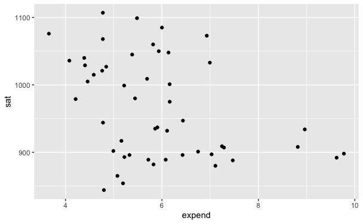

```r
ggplot(data=SAT, aes(x=expend, y=sat)) + geom_point()
```

3. The scatterplot does not seem to follow a linear trend. The points are clustered and all over the place, especially to the left. Accordingly, the strength is very weak and there does not seem to be a direct correlation. It seems the scatterplot seems to follow a weak, negative slope.
4. No, the states with the highest SAT scores have some of the lowest expenditures. This is different than what I thought initially.
5. Smaller states may spend per student. Maybe states with small student populations may not have lower SAT scores ‘drag’ the average SAT score down.

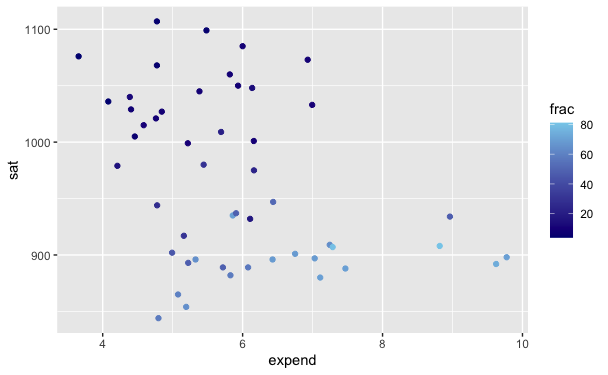

```r
ggplot(data=SAT, aes(x=expend, y=sat, color=frac)) + geom_point() + scale_color_gradient(low='navy',high='skyblue')
```

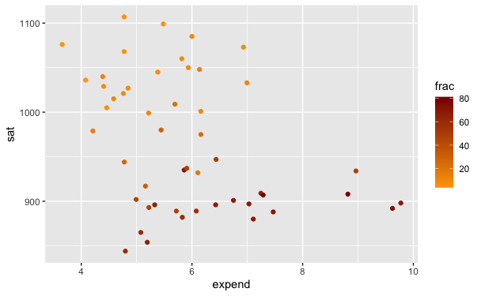

```r
ggplot(data=SAT, aes(x=expend, y=sat, color=frac)) + geom_point() + scale_color_gradient(low='orange',high='darkred')
```

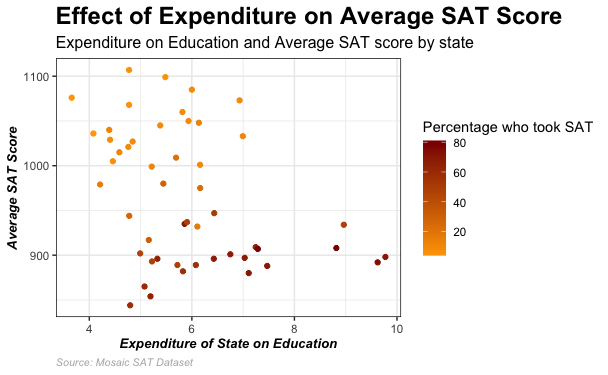

```r
ggplot(data=SAT, aes(x=expend, y=sat, color=frac)) + geom_point() +
  scale_color_gradient(low='orange',high='darkred') +
  labs(
    title='Effect of Expenditure on Average SAT Score',
    subtitle = 'Expenditure on Education and Average SAT score by state',
    x='Expenditure of State on Education',
    y='Average SAT Score',
    color='Percentage who took SAT',
    caption ='Source: Mosaic SAT Dataset'
) + theme_bw() +
  theme(
  plot.title = element_text(face='bold',size=18),
  plot.subtitle = element_text(color='black',size=12),
  axis.title.x = element_text(face='bold.italic',size=10),
  axis.title.y = element_text(face='bold.italic',size=10),
  plot.caption = element_text(color='grey70',face='italic',size=8,hjust=0),
  panel.border = element_rect(color='black', fill=NA))
```